# Used Car Dealership Data Project

## Used Car Dealership Data Project

```python
import matplotlib
from datascience import *
%matplotlib inline
import matplotlib.pyplot as plots
import numpy as np
plots.style.use('fivethirtyeight')
from scipy import stats
```

As of August 2004, a large Toyota car dealership offers purchasers of new Toyota cars the option to buy their used car as part of a trade-in. The dealer then sells the used cars for a small profit. The `ToyotaCorolla.csv` data includes the sales price and other information on the used cars, such as its age, mileage, fuel type, and engine size. A description of each of these variables is provided below. The total number of records in the dataset is 718 Toyota cars in the inventory.

| Variables | Descriptions |
| --- | --- |
| *Price* | Offer Price in EUROs |
| _Age_08*04* | Age in months as in August 2004 |
| _Mfg*Year* | Year of Manufacture of the car |
| *KM* | Accumulated Kilometers on odometer |
| *Automatic* | Automatic ( (Yes=1, No=0) |
| *Boardcomputer* | Boardcomputer (Yes=1, No=0)free form of SO2 (prevents microbial growth and the oxidation of wine) |
| _Sport*Model* | Sport Model (Yes=1, No=0) |
| *Cylinders* | Number of cylinders |
| _Central*Lock* | Central Lock (Yes=1, No=0) |
| _Power*Steering* | Power Steering (Yes=1, No=0) |
| *Weight* | Weight in Kilograms |
| _Parking*Assistant* | Parking assistance system (Yes=1, No=0) |
| *ABS* | Anti-Lock Brake System (Yes=1, No=0) |
| _Fuel*Type* | Fuel Type (Petrol, Diesel, CNG) |

```python
toyota = Table.read_table('ToyotaCorolla.csv').select(
    ['Price', 'Age_08_04', 'Mfg_Year', 'KM', 'Automatic',
    'Boardcomputer', 'Sport_Model', 'Cylinders',
    'Central_Lock', 'Power_Steering', 'Weight', 'Parking_Assistant',
    'Weight','Parking_Assistant', 'ABS', 'Fuel_Type'])
toyota.take(np.arange(5))
```

| Price | Age_08_04 | Mfg_Year | KM | Automatic | Boardcomputer | Sport_Model | Cylinders | Central_Lock | Power_Steering | Weight | Parking_Assistant | ABS | Fuel_Type |
| --- | --- | --- | --- | --- | --- | --- | --- | --- | --- | --- | --- | --- | --- |
| 13750 | 23 | 2002 | 72937 | 0 | 1 | 0 | 4 | 1 | 1 | 1165 | 0 | 1 | Diesel |
| 14950 | 26 | 2002 | 48000 | 0 | 1 | 0 | 4 | 0 | 1 | 1165 | 0 | 1 | Diesel |
| 12950 | 32 | 2002 | 61000 | 0 | 1 | 0 | 4 | 1 | 1 | 1170 | 0 | 1 | Diesel |
| 18600 | 30 | 2002 | 75889 | 0 | 1 | 0 | 4 | 1 | 1 | 1245 | 0 | 1 | Diesel |
| 12950 | 23 | 2002 | 71138 | 0 | 1 | 0 | 4 | 0 | 1 | 1105 | 0 | 1 | Diesel |

## The typical price of a used Toyota car.

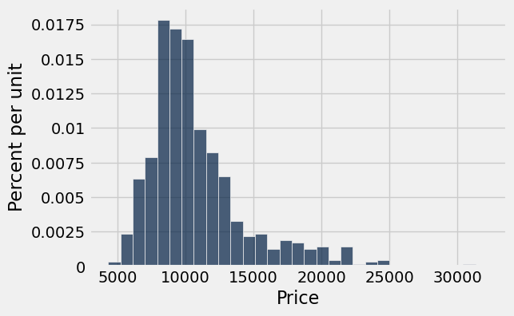

```python
toyota_bins = np.arange(4300, 33000, 900)

toyota.hist('Price', bins=toyota_bins)
```

This histogram is right skewed due to the fact that the tail is on the right side of the histogram. The bulk of the data is on the left with fewer values concentrated on the right side. Most values are clustered at lower levels, with fewer data points at the higher end, indicating a skew of the data.

```python
# Measure of center
measure_of_center = np.median(toyota.column('Price'))
measure_of_center
```

```
9900.0
```

```python
# Measure of spread
measure_of_spread = percentile(75, toyota.column('Price')) - percentile(25, toyota.column('Price'))
measure_of_spread
```

```
3450
```

We would use the median and iqr as choices of measures for this data because they are resistant statistics, meaning they are resitant to the impact of outliers when the data is skewed. After visualizing the data with a histogram, we were able to see that the data is right skewed, meaning that high values will pull the mean and standard deviation upward (since the mean and standard deviation is not resistant to outliers). So, in this case we would use median and iqr since they are robust statistics that woun't be inaccurately affecte by the outliers and skew of the data.

```python
our_sample = toyota.sample(100, with_replacement=False)

our_sample_median = np.median(our_sample.column('Price'))

boot_sample = our_sample.sample(100, with_replacement=True)
```

```python
def one_bootstrap_median():
    single_sample = our_sample.sample()
    return np.median(single_sample.column('Price'))
```

```python
one_bootstrap_median()
```

```
9250.0
```

```python
bootstrap_medians = make_array()

for i in np.arange(5000):
    new_median = one_bootstrap_median()
    bootstrap_medians = np.append(bootstrap_medians, new_median)
```

```python
left = percentile(5, bootstrap_medians)
right = percentile(95, bootstrap_medians)

left, right
```

```
(9190.0, 9950.0)
```

## Question 5

Depending on the model of a car and the year of manufacture, used car prices can vary. As of August 2004, the manager of the car dealership where the `ToyotaCorolla.csv` data set was collected has Toyota cars with different years of manufacture(in particular, cars manufactured in the categories of the years 1998 - 2004). To meet different customer needs for used cars, the manager of the Toyota car dealership offering the promotion claims that he maintains the following inventory proportions of Toyota cars by `Year of manufacture(MFG_Year)`: 1998(22%), 1999(28%), 2000(11%), 2001(8%), 2002(10%), 2003(9%), and 2004(12%).

The goal of this problem is to assess whether the actual observed proportions of toyota cars in the `ToyotaCorolla.csv` data set, grouped by `Year of manufacture(MFG_Year)`, supports the manager's claim or represents a significant departure from the claim.

Using the following hypotheses:

**Null Hypothesis:** The proportions of used Toyota cars by year of manufacture shows that the data is a random sample drawn from a population having the proportions claimed by the manager.

**Alternative Hypothesis**: The proportions of used Toyota cars by year of manufacture `does not` show that the data is a random sample drawn from a population having the proportions claimed by the manager.

```python
sample_size = toyota.num_rows
sample_size
```

```
718
```

```python
actual_1998 = (toyota.where('Mfg_Year', are.equal_to(1998))).num_rows / sample_size
actual_1999 = (toyota.where('Mfg_Year', are.equal_to(1999))).num_rows / sample_size
actual_2000 = (toyota.where('Mfg_Year', are.equal_to(2000))).num_rows / sample_size
actual_2001 = (toyota.where('Mfg_Year', are.equal_to(2001))).num_rows / sample_size
actual_2002 = (toyota.where('Mfg_Year', are.equal_to(2002))).num_rows / sample_size
actual_2003 = (toyota.where('Mfg_Year', are.equal_to(2003))).num_rows / sample_size
actual_2004 = (toyota.where('Mfg_Year', are.equal_to(2004))).num_rows / sample_size

actual_1998, actual_1999, actual_2000, actual_2001, actual_2002, actual_2003, actual_2004
```

```
(0.27298050139275765,
 0.30779944289693595,
 0.15598885793871867,
 0.13370473537604458,
 0.05988857938718663,
 0.05153203342618384,
 0.018105849582172703)
```

```python
car_years = Table().with_columns(
    'Years', make_array('1998', '1999', '2000', '2001', '2002', '2003', '2004'),
    'Actual_Prop', make_array(actual_1998, actual_1999, actual_2000, actual_2001, actual_2002, actual_2003, actual_2004),
    'Manager_Predicted_Prop', make_array(0.22, 0.28, 0.11, 0.08, 0.10, 0.09, 0.12)
)

car_years
```

| Years | Actual_Prop | Manager_Predicted_Prop |
| --- | --- | --- |
| 1998 | 0.272981 | 0.22 |
| 1999 | 0.307799 | 0.28 |
| 2000 | 0.155989 | 0.11 |
| 2001 | 0.133705 | 0.08 |
| 2002 | 0.0598886 | 0.1 |
| 2003 | 0.051532 | 0.09 |
| 2004 | 0.0181058 | 0.12 |

```python
def tvd(distribution_1, distribution_2):
    return sum(abs(distribution_1 - distribution_2)) / 2
```

```python
diffs = abs(car_years.column('Manager_Predicted_Prop') - car_years.column('Actual_Prop'))
car_years_with_difference = car_years.with_column("Difference", diffs)
sum(car_years_with_difference.column('Difference')) / 2
```

```
0.18047353760445681
```

```python
observed_tvd = tvd(car_years.column('Manager_Predicted_Prop'), car_years.column('Actual_Prop'))
observed_tvd
```

```
0.18047353760445681
```

```python
toyota_sample_size = toyota.num_rows
model_proportion = car_years.column('Actual_Prop')
simulated_distribution = sample_proportions(toyota_sample_size, model_proportion)
simulated_distribution
```

```
array([ 0.28133705,  0.27994429,  0.14345404,  0.15320334,  0.06267409,
        0.06267409,  0.01671309])
```

```python
car_years_with_simulated = car_years.with_column('Simulated', simulated_distribution)
car_years_with_simulated
```

| Years | Actual_Prop | Manager_Predicted_Prop | Simulated |
| --- | --- | --- | --- |
| 1998 | 0.272981 | 0.22 | 0.281337 |
| 1999 | 0.307799 | 0.28 | 0.279944 |
| 2000 | 0.155989 | 0.11 | 0.143454 |
| 2001 | 0.133705 | 0.08 | 0.153203 |
| 2002 | 0.0598886 | 0.1 | 0.0626741 |
| 2003 | 0.051532 | 0.09 | 0.0626741 |
| 2004 | 0.0181058 | 0.12 | 0.0167131 |

```python
tvd(car_years_with_simulated.column('Simulated'), car_years_with_simulated.column('Actual_Prop'))
```

```
0.041782729805013949
```

```python
def simulated_tvd():
    simulated_distribution = sample_proportions(toyota_sample_size, model_proportion)
    return tvd(simulated_distribution, car_years_with_simulated.column('Actual_Prop'))
```

```python
simulated_tvd()
```

```
0.05292479108635096
```

```python
tvds = make_array()

num_simulations = 10_000

for i in np.arange(num_simulations):
    tvds = np.append(tvds, simulated_tvd())
```

[figure not shown]

```python
Table().with_column('tvds', tvds).hist()
plots.plot([observed_tvd, observed_tvd], [0, 36], color='red', lw=2);
```

```python
p_value = sum(tvds >= observed_tvd) / num_simulations
p_value
```

```
0.0
```

We would reject the null hypothesis at the 0.05 significance level because our p-value (of 0) is less than our alpha of 0.05. This is because the tail beyond the observed test statistic is 0 so the observed test statistic is far from what the null hypothesis predicts. The data supports the alternate hypothesis better. In simple terms, because the p-value is 0, it provides very strong evidence that the proportions of used Toyota cars by year of manufacture does not show that the data is a random sample drawn from a population having the proportions claimed by the manager. Since the calculated p-value is much less than 0.05, it suggests that it is highly unlikely to observe that the proportions of used Toyota cars by year of manufacture does infact show that the data is a random sample drawn from a population having the proportions claimed by the manager. Therefore, we conclude that the observed proportions of used Toyota cars by year of manufacture significantly differ from the manager's claimed proportions, indicating a lack of support for the manager's inventory claims.

## Are used, `sports-model` Toyota cars(_Sport*Model=1*) on the lot more expensive than Toyota cars that are not `sports-model`(_Sport*Model=0*)? Does this data suggest that the mean price of used, sports-model Toyota cars is higher than those that are not sports-model? The *Sport_ Model* variable in the data set is used to characterize where a Toyota car is a sports model or not.

```python
price_and_sport_model = toyota.select('Price', 'Sport_Model')
means_table = price_and_sport_model.group('Sport_Model', np.average)
means_table
```

| Sport_Model | Price average |
| --- | --- |
| 0 | 10396 |
| 1 | 11586.4 |

```python
observed_value = means_table.column(1).item(1) - means_table.column(1).item(0)
observed_value
```

```
1190.3203853211016
```

```python
def difference_of_means(table, num_var, categ_var):
    """Takes name of the table, column label of numerical variable, column label of group/categorical variable
    Returns the difference between sample means of the two groups"""
    reduced = table.select(categ_var, num_var)
    means_table = reduced.group(categ_var, np.average)
    means = means_table.column(1)
    observed_difference = means.item(1) - means.item(0)
    return observed_difference
```

```python
difference_of_means(toyota, 'Price', 'Sport_Model')
```

```
1190.3203853211016
```

```python
shuffled_labels = toyota.sample(with_replacement=False).column('Sport_Model')
```

```python
def one_simulated_difference(table, num_var, categ_var):
    shuffled_labels = table.sample(with_replacement=False).column(categ_var)
    shuffled_table = table.select(num_var).with_column('Shuffled Label', shuffled_labels)
    return difference_of_means(shuffled_table, num_var, 'Shuffled Label')
```

```python
one_simulated_difference(toyota, 'Price', 'Sport_Model')
```

```
138.4767339449536
```

```python
differences = make_array()

for i in np.arange(1000):
    differences = np.append(differences, one_simulated_difference(toyota, 'Price', 'Sport_Model'))
```

[figure not shown]

```python
Table().with_column('Difference Between Group Means', differences).hist()
plots.plot([observed_value, observed_value], [0, 0.0013], color='red', lw=2);
```

```python
p_value = sum(differences >= observed_value) / 1000
p_value
```

```
0.0
```

We would reject the null hypothesis at the 0.05 significance level because our p-value (of 0) is less than our alpha of 0.05. This is because the tail beyond the observed test statistic is 0 so the observed test statistic is far from what the null hypothesis predicts. The data supports the alternate hypothesis better. In simple terms, because the p-value is 0, it provides very strong evidence that used sports-model Toyota cars are more expensive than non-sports-model Toyota cars. Since the calculated p-value is much less than 0.05, it suggests that it is highly unlikely to observe that there is no difference in prices between used sports-model Toyota cars and non-sports-model Toyota cars. Therefore, we conclude that the mean price of used sports-model Toyota cars is significantly higher than that of non-sports-model cars.